# Case Study 1

AKSTA Statistical Computing

Maximilian Kraus, Lukas Vater, Hannah Weichhart

```r
library(knitr)

ai_usage <- data.frame(
  AI_usage = c("Improving existing code", "Text correction", "Help with generating plots"),
  Task_1 = c("none", "little", "none"),
  Task_2 = c("little", "none", "none"),
  Task_3 = c("little", "medium", "heavy"),
  Task_4 = c("little", "medium", "heavy"),
  Task_5 = c("none", "none", "none"),
  Task_6 = c("little", "little", "none")
)

kable(ai_usage, caption = " AI Usage for Different Tasks")
```

AI Usage for Different Tasks

| AI_usage | Task_1 | Task_2 | Task_3 | Task_4 | Task_5 | Task_6 |
| --- | --- | --- | --- | --- | --- | --- |
| Improving existing code | none | little | little | little | none | little |
| Text correction | little | none | medium | medium | none | little |
| Help with generating plots | none | none | heavy | heavy | none | none |

# 1. Ratio of Fibonacci numbers (1 point)

## a.

Write two different R functions which return the sequence $r_{i}=F_{i+1}/F_i$ for $i=1,\ldots,n$ where $F_i$ is the $i$th Fibonacci number, once using `for` and once using `while`.

```r
# for
fib_for <- function(n) {
  f <- c(1, 1)

  for (i in 3:(n + 1)) {
    f[i] <- f[i - 1] + f[i - 2]
  }

  return(f[2:(n + 1)] / f[1:n])
}

# while
fib_while <- function(n) {
  f <- c(1, 1)

  while (length(f) < n + 1) {
    n_jetzt <- length(f)
    f[n_jetzt + 1] <- f[n_jetzt] + f[n_jetzt - 1]
  }

  return(f[2:(n + 1)] / f[1:n])
}
```

## b.

Benchmark the two functions for $n=200$ and $n=2000$ (you can use package **microbenchmark** or package **bench** for this purpose). Which function is faster?

```r
bm_200 <- microbenchmark(fib_for(200), fib_while(200), times = 100)
bm_2000 <- microbenchmark(fib_for(2000), fib_while(2000), times = 100)

print(bm_200)
```

```
## Unit: microseconds
##            expr   min    lq    mean median     uq     max neval
##    fib_for(200)  63.5  81.1 363.314  89.60 106.05 26394.0   100
##  fib_while(200) 112.9 135.2 251.556 145.25 165.45  6904.4   100
```

```r
print(bm_2000)
```

```
## Unit: microseconds
##             expr   min     lq     mean  median     uq    max neval
##    fib_for(2000) 445.1 536.70  643.050  595.80  656.1 2338.7   100
##  fib_while(2000) 768.3 899.15 1209.048 1038.45 1177.7 4391.1   100
```

## c.

Plot the sequence for $n=100$. For which $n$ does it start to stabilize to a value? What number does the sequence converge to?

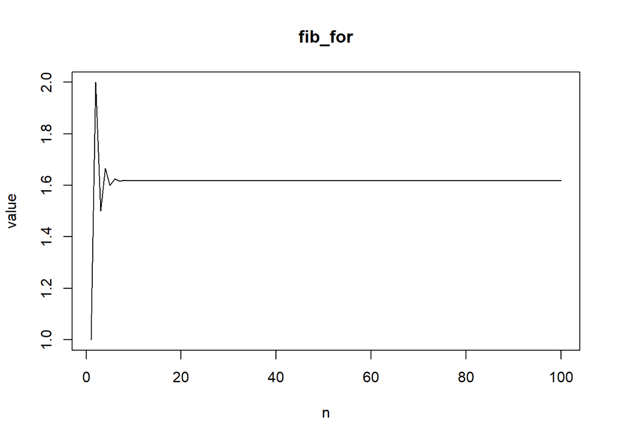

```r
r <- fib_for(100)
plot(r, type = "l", main = "fib_for", xlab = "n", ylab = "value")
```

This sequence converges to the golden ratio (~1.618). It stabilizes at $n$ = 10.

# 2. Gamma function (1 point)

## a.

Write a function to compute the following for $n$ a positive integer using the `gamma` function in base R.
$$\rho_n =\frac{\Gamma((n-1)/2)}{\Gamma(1/2)\Gamma((n -
2)/2)}$$

```r
roh_n <- function(n){
  if((is.integer(n) == FALSE) | (n<0)){
    print('n is not a positive integer!')}
  else{
    gamma((n-1)/2)/(gamma(1/2)*gamma((n-2)/2))}
}
```

## b.

Try $n = 2000$. What do you observe? Why do you think the observed behavior happens?

```r
roh_n(2000L)
```

```
## [1] NaN
```

For large n the function returns a NaN value. This could be, because the gamma function returns inf values for those n, as the resulting number is too large for R to process.

## c.

Write an implementation which can also deal with large values of $n>1000$.

```r
lroh_n <- function(n){
  if((is.integer(n) == FALSE) | (n<0)){
    print('n not a positive integer!')}
  else{
    exp(lgamma((n-1)/2)-(lgamma(0.5)+lgamma((n-2)/2)))}
}
lroh_n(2000L)
```

```
## [1] 17.83009
```

Instead of the gamma function, here the lgamma function (the natural logarithm of gamma) is used for the calculations and afterwards the exponential function calculated. As lgamma results in lower values, R can handle these calculations better.

## d.

Plot $\rho_n/\sqrt{n}$ for different values of $n$. Can you guess the limit of $\rho_n/\sqrt{n}$ for $n \rightarrow\infty$?

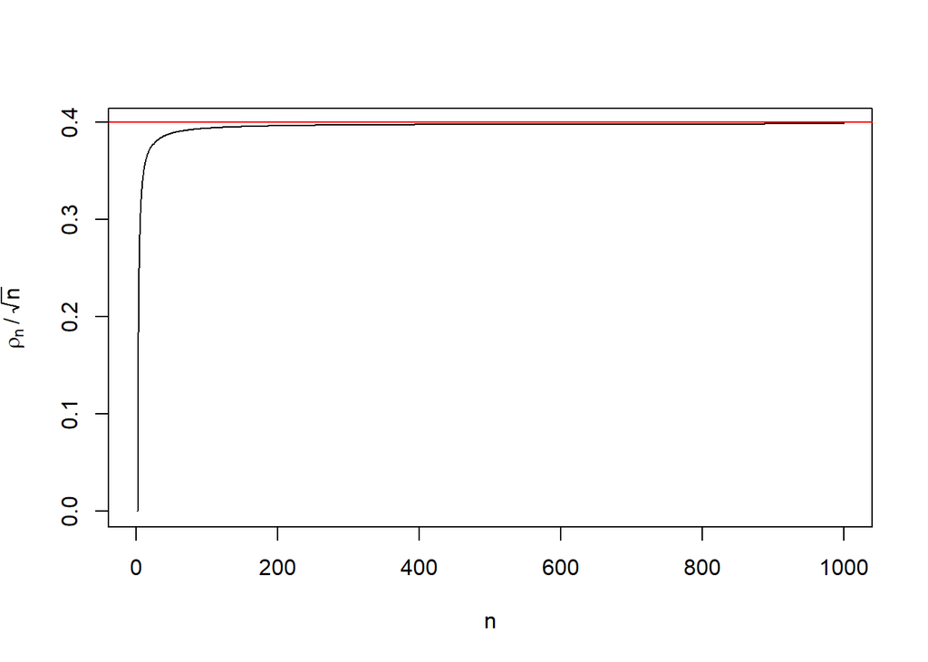

The limit of $\rho_n/\sqrt{n}$ for $n \rightarrow\infty$ seems to be 0.4.

# 3. Weak law of large numbers (1.5 points)

The law of large numbers states that if you repeat an experiment independently a large number of times and average the result, what you obtain should be close to the expected value. Formally, the weak law of large numbers states that if $X_1, X_2, \ldots X_n$ are independently and identically distributed (iid) random variables with a finite expected value $E(X_i)=\mu<\infty$, then, for any $\epsilon > 0$ $\lim_{n\rightarrow \infty} P(|\bar X_n-\mu|>\epsilon)=0$ where $\bar X_n=\frac{X_1+X_2+\ldots+X_n}{n}$ is the sample mean (the sample mean converges in probability to the expected value).

## a.

- In R, simulate rolling a fair 6-sided die $n=10\,000$ times using vectorized functions.
- After each roll, compute the cumulative mean of all previous rolls.
- Plot the running average against the number of rolls and comment on the result.

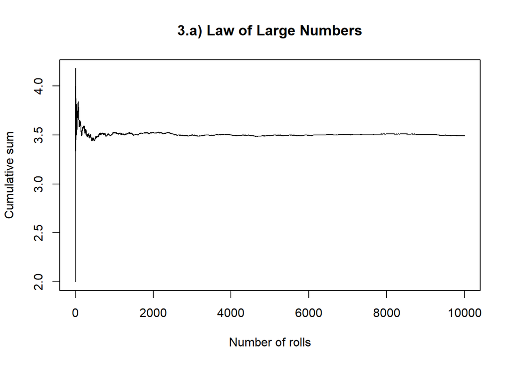

```r
set.seed(100)
n <- 10000

# Simulate rolls
rolls <- sample(1:6, n, replace = TRUE)
cum_mean <- cumsum(rolls) / 1:n

# Plot cumulative mean
plot(cum_mean, type="l",
  xlab = "Number of rolls",
  ylab = "Cumulative sum",
  main = "3.a) Law of Large Numbers")
```

It can be seen, that at the first few hundred rolls the cumulative mean fluctuates and then converges towards the expected value 3.5.

## b.

- Replicate the die-rolling experiment $M=50$ times using a for loop. This will result in $50$ paths which you can plot against the number of rolls.
- Plot all 50 paths on the same graph to observe the variation in the running averages.

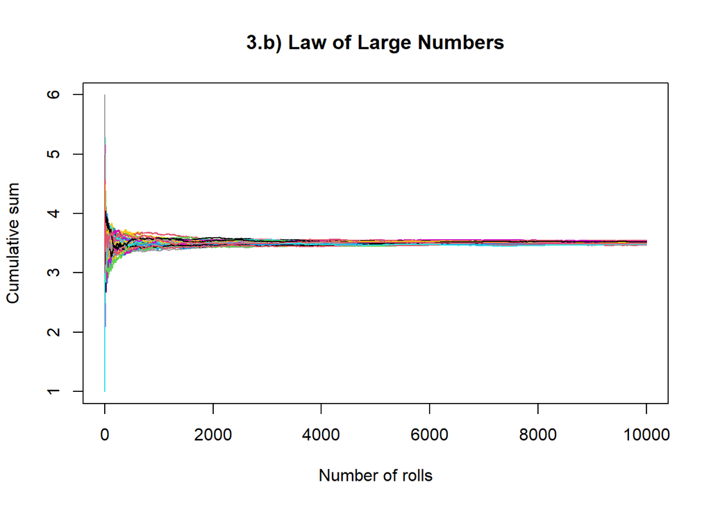

```r
set.seed(100)
n <- 10000
M <- 50

plot(1, type="n", xlim=c(1, n), ylim=c(1,6),
  xlab = "Number of rolls",
  ylab = "Cumulative sum",
  main = "3.b) Law of Large Numbers")

for (i in 1:M) {
  rolls <- sample(1:6, n, replace = TRUE)
  cum_mean <- cumsum(rolls) / 1:n
  lines(cum_mean, col=i)
}
```

## c.

What is the theoretical expected value of a fair 6-sided die?

It is 3.5

## d.

Comment on how the running mean of the paths behaves relative to the expected value as $n$ increases.

As shown in plot 3.b, at n=1 the running mean can take any value between 1 and 6. However, as n increases, it quickly falls within the range [3, 4] and gradually converges toward the expected value of 3.5.

## e.

- Modify the code in b. to use a while loop.
- Stop the loop when the proportion of replications where the difference between the running average and the expected value lies outside the interval $[-\epsilon,\epsilon]$ is less than 0.05. Use $\epsilon = 0.01$.
- How high is $n$ at the end of the loop?

```r
set.seed(100)
n <- 0
M <- 50
cum_sum <- rep(0, M)
epsilon <- 0.01
prop <- 1

while (prop >= 0.05) {
  n <- n + 1
  rolls <- sample(1:6, M, replace = TRUE)
  cum_sum <- cum_sum + rolls
  cum_mean <- cum_sum / n
  prop <- sum(abs(cum_mean - 3.5) > epsilon) / M
}
print(paste("n: ", n))
```

```
## [1] "n:  64789"
```

## f.

- Repeat the analysis in b, but instead of simulating from a discrete uniform distribution, simulate from a continuous standard cauchy distribution using `rcauchy()`. The (standard) cauchy distribution arises from the ratio of two independent mean zero (standard) normally distributed random variables.
- Plot the running mean against increasing $n$. Comment on whether the weak Law of Large Numbers seems to hold for this distribution. Explain why or why not.

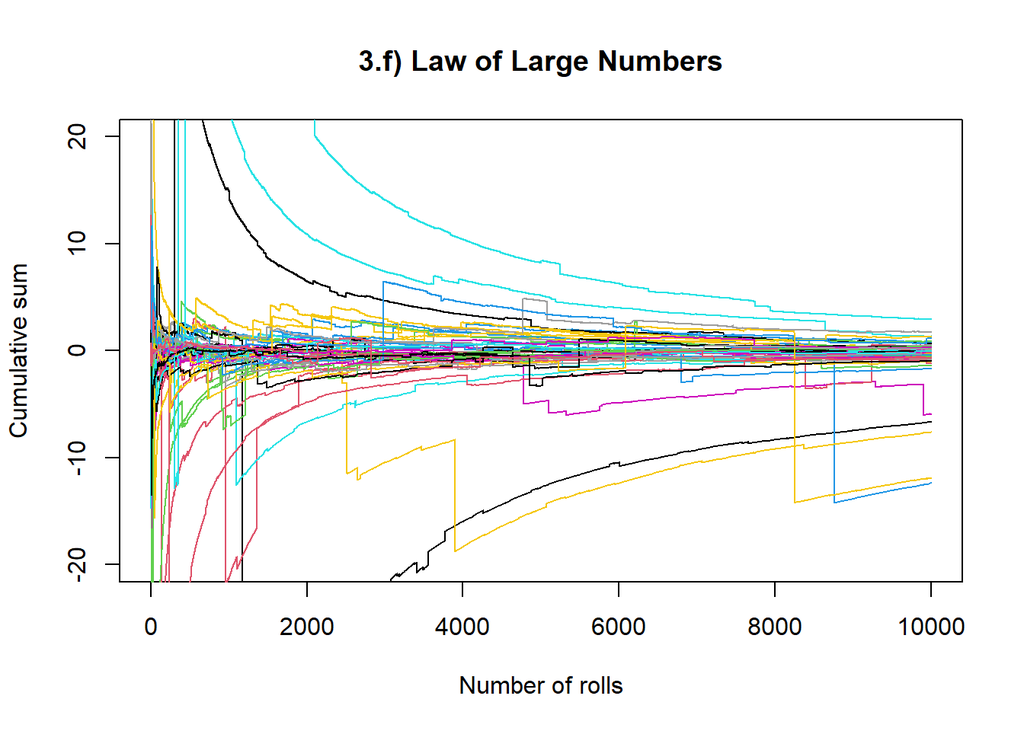

```r
set.seed(100)
n <- 10000
M <- 50

plot(1, type="n", xlim=c(1, n), ylim=c(-20, 20),
  xlab = "Number of rolls",
  ylab = "Cumulative sum",
  main = "3.f) Law of Large Numbers")

for (i in 1:M) {
  rolls <- rcauchy(n)
  cum_mean <- cumsum(rolls) / 1:n
  lines(cum_mean, col=i)
}
```

There is a general trend of the running mean moving toward zero (the expected value), but occasionally a large outlier appears and dramatically affects the running mean. As a result, the weak law of large numbers does not appear to hold for the Cauchy distribution.

# 4. Central limit theorem (1.5 points)

The central limit theorem states that, under certain conditions, the sum of a large number of random variables is approximately normal. Consider the case where $X_1, X_2,\ldots,X_n$ are i.i.d. random variables with finite expected values ($E(X_i)=\mu<\infty$) and variances $(Var(X_i)=\sigma^2<\infty)$. The central limit theorem states that the cumulative distribution function (CDF) of the normalized random variable
$$Z_n = \frac{\bar X_n - \mu}{\sigma/\sqrt{n}}$$
converges to the standard normal CDF as $n\rightarrow\infty$.

## a.

Derive the expected value of the sample mean $\bar X_n=\frac{X_1+X_2+\ldots+X_n}{n}$.

$E(X_i) = \mu$
$$E(\bar{X}_n) = E\left(\frac{1}{n} \sum_{i=1}^{n} X_i \right)
= \frac{1}{n} \sum_{i=1}^{n} E(X_i)
= \frac{1}{n} \cdot n\mu
= \mu$$

## b.

Derive the variance of the sample mean $\bar X_n=\frac{X_1+X_2+\ldots+X_n}{n}$.

$Var(X_i) = \sigma^2$
$$\mathrm{Var}(\bar{X}_n)
= \mathrm{Var}\left(\frac{1}{n} \sum_{i=1}^{n} X_i \right)
= \frac{1}{n^2} \mathrm{Var}\left( \sum_{i=1}^{n} X_i \right)
= \frac{1}{n^2} \sum_{i=1}^{n} \mathrm{Var}(X_i)
= \frac{1}{n^2} \cdot n \sigma^2
= \frac{\sigma^2}{n}$$

## c.

The central limit theorem makes few assumption on the distribution of the random variables $X_i$. Consider again the die-rolling experiment where $X_i$ is the random variable giving the number in roll $i$.

- Simulate Die Rolls: For each value of $n$ (where $n=\{100,1000,10000\}$), simulate rolling a die $n$ times. Record the mean of the $n$ rolls.
- Repeat the above process $M=100$ times for each value of $n$. This will give you 100 sample means for each $n$.
- Plot a histogram of the 100 sample means for each value of $n$. Observe the shape of the histograms.
- Discuss how the distribution of the sample means changes as $n$ increases. Comment on whether the histograms appear to approach a normal distribution as $n$, illustrating the Central Limit Theorem.

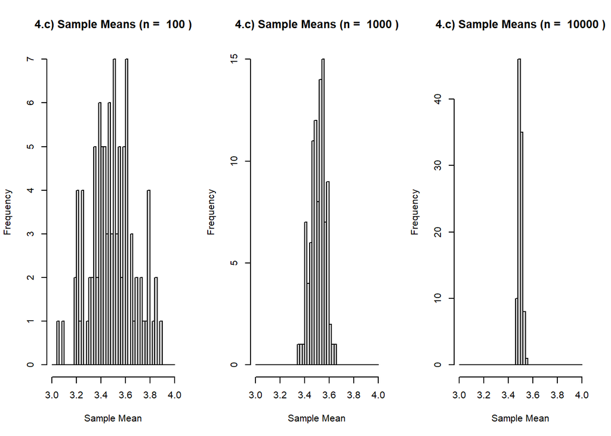

```r
set.seed(100)

# Function to simulate means
simulateMeans <- function(n, m = 100) {
  means <- numeric(m)
  for (i in 1:m) {
    rolls <- sample(1:6, size = n, replace = TRUE)
    means[i] <- mean(rolls)
  }
  return(means)
}

n_values <- c(100, 1000, 10000)

# Layout for plots
par(mfrow = c(1, 3))

# Simulate and plot
for (n in n_values) {
  means <- simulateMeans(n)
  hist(means,
    main = paste("4.c) Sample Means (n = ", n, ")"),
    xlab = "Sample Mean",
    breaks = seq(3, 4, by = 0.02),
    xlim = c(3,4))
}
```

As n increases, the distribution of the sample means becomes narrower, meaning more of the sample means are close to the expected value μ = 3.5. The shape of the distribution approaches a normals distribution.

## d.

Compute expected value $\mu$ and the variance $\sigma^2$ for the random variable $X_i$ (giving the number in die-roll $i$), which follows a discrete uniform distribution.

```r
# Dice values
X <- 1:6

# Expected value
mu <- mean(X)
mu
```

```
## [1] 3.5
```

```r
# Variance
sigma2 <- mean(X^2) - mu^2
sigma2
```

```
## [1] 2.916667
```

## e.

Now that you computed $\mu$ and $\sigma^2$, consider $Z_n$.

- For each value of $n$ (where $n=\{100,1000,10000\}$) and for $M=\{100,1000,10000\}$ replications, simulate the rolling of $n$ dice and calculate the $Z_n$.
- Plot histograms of $Z_n$ for each combination of $n$ and $M$.
- Discuss how the distribution of $Z_n$ changes as $n$ and $M$ increase. Comment on whether the distributions of $Z_n$ appear to approach a normal distribution, illustrating the Central Limit Theorem.

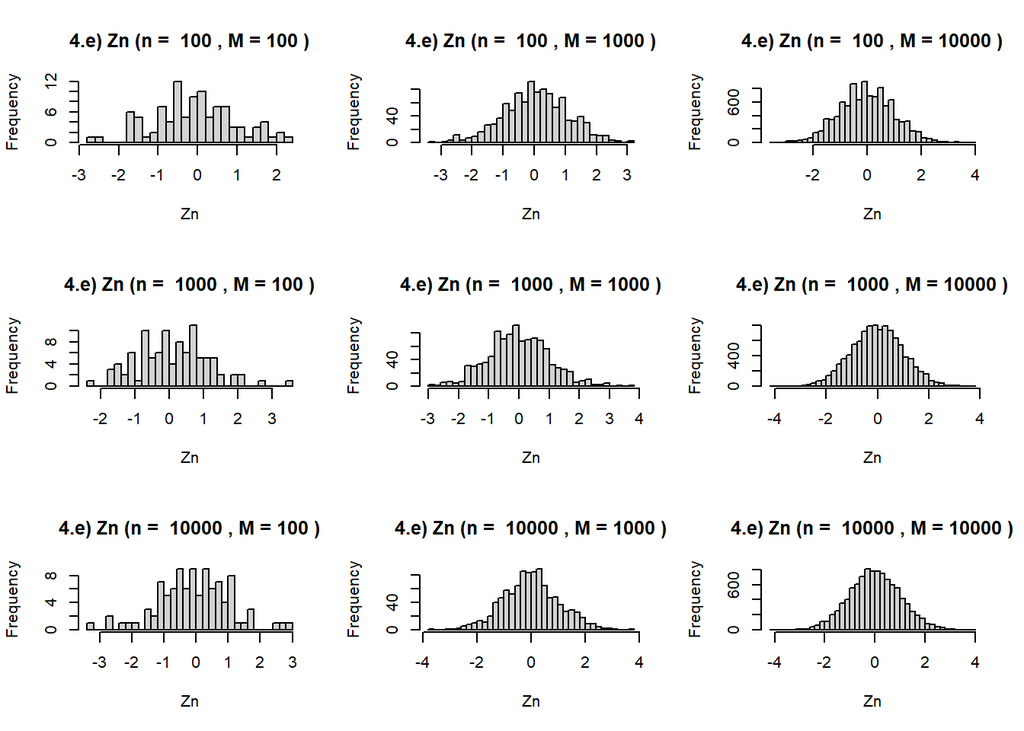

```r
set.seed(100)

mu <- 3.5
sigma <- sqrt(mean((1:6)^2) - mu^2)

simulateZn <- function(n, m) {
  Zn <- numeric(m)

  for (i in 1:m) {
    rolls <- sample(1:6, n, replace = TRUE)
    x_bar <- mean(rolls)
    Zn[i] <- (x_bar - mu) / (sigma / sqrt(n))
  }
  return(Zn)
}

n_values <- c(100, 1000, 10000)
m_values <- c(100, 1000, 10000)

# 9 plots
par(mfrow = c(3,3))

for (n in n_values) {
  for (m in m_values) {
    Zn <- simulateZn(n, m)
    hist(Zn,
      main = paste("4.e) Zn (n = ", n, ", M =", m, ")"),
      xlab = "Zn",
      breaks = 30)
  }
}
```

# 5. Readable and efficient code (1 points)

Read over the code below.

## a.

Explain (in text) what the code does.

The first Code fits the random, normally distributed vectors x and z by a linear model, if enough observations fulfill the required size. The x vector is then calculated with a sinusoidal function of the residuals.

The second Code performs a kind of cross validation, as one fourth of the data is first omitted for the calculation of a linear model of two random, normally distributed vectors x and y, and the predicted. For each of the predictions the RMSE is calculated.

## b.

Explain (in text) what you would change to make the code more readable.

A for loop shortens the code significantly and one could easily expand the number of steps by increasing the range iterated over.

A for loop also shortens the code and by adding the variables nb_sets and stepsize the amount of cross-validations performed can also be easily adapted.

## c.

Change the code according to b. and wrap it in a function. This function should have at most 10 lines (without adding commands to more lines such as `x <- 1; y <- 2`. Such commands will count as 2 lines!). Check that the function called on the same input outputs the same as the provided code.

```r
set.seed(1)
x_adapted <- rnorm(100)
z <- rnorm(100)
#Adapted Code 1
for (i in 1:4){
  if(sum(x_adapted >= 0.001*i)<i){
    stop(paste("step", i,"requires",i,"observation(s) with value >=", 0.001*i))
  }
  fit <- lm(x_adapted ~ z)
  r <- fit$residuals
  x_adapted <- i*sin(r) + i*0.01
}
x_adapted
```

```
##          1          2          3          4          5          6          7
## -1.0992886  1.4796352 -0.6516207  0.7865093  3.7873388 -0.2055179  3.8327000
##          8          9         10         11         12         13         14
##  2.0871822  3.2219962 -3.0933769  0.6399144  4.0325676 -0.7808135 -0.8326365
##         15         16         17         18         19         20         21
##  0.7073736 -3.2414091 -2.8376440  0.9776866  1.5608532  3.0227535  1.0117977
##         22         23         24         25         26         27         28
##  1.8922308 -1.0474880 -0.4636773  2.8222909 -3.4535959 -3.9591095 -0.5208395
##         29         30         31         32         33         34         35
## -1.9366900  4.0313764  0.7254867 -3.7758444  4.0170200 -3.2639844 -0.4572754
##         36         37         38         39         40         41         42
## -2.5234159 -2.5371644 -3.4025549  0.6499197  1.7909888 -3.9557224 -3.5524879
##         43         44         45         46         47         48         49
##  2.0066135  3.2915276 -0.9643167 -0.8508112  3.8888448  1.7701559 -3.8041387
##         50         51         52         53         54         55         56
##  0.9535984  4.0340296 -1.0616984  3.8507707 -0.6058260  0.4776386  0.5361922
##         57         58         59         60         61         62         63
## -2.6133980 -0.5347483  3.0972939 -3.9543801  1.0621806 -3.1799992  2.4340472
##         64         65         66         67         68         69         70
## -2.1800910 -0.7436082  1.3185751 -0.4879213  0.4959666  0.8098709  0.7497175
##         71         72         73         74         75         76         77
##  3.9472930 -0.6991699  2.9570004 -0.4460233 -0.5400743  3.3793674 -1.9905970
##         78         79         80         81         82         83         84
## -2.7888504 -1.2126583 -0.9658716 -1.4647239 -3.9458928  0.7544273 -0.7574175
##         85         86         87         88         89         90         91
##  3.0949240  3.7880760  1.0486519 -3.3233027  3.9897095  3.1324172 -1.4436191
##         92         93         94         95         96         97         98
##  0.7777796  0.5976052  2.3300564  0.5549268  3.2229364 -0.2445148 -1.4071426
##         99        100
## -0.4052558 -1.9274082
```

```r
set.seed(1)
x <- rnorm(1000)
y <- 2 + x + rnorm(1000)
df <- data.frame(x, y)
r_adapted <- c()
#adapted Code 2
nb_sets <- 4
stepsize <- nrow(df)/nb_sets
for (j in 1:nb_sets){
  cat("Step", j, "\n")
  section <- (1+stepsize*(j-1)):(stepsize*j)
  fit <- lm(y~x, data = df[-section,])
  p1 <- predict(fit, newdata = df[section,])
  r_adapted <- c(r_adapted, sqrt(mean((p1 - df[section, 'y'])^2)))
}
```

```
## Step 1
## Step 2
## Step 3
## Step 4
```

```r
r_adapted
```

```
## [1] 1.0249956 0.9952113 1.0685500 1.0707264
```

```r
set.seed(1)
x <- rnorm(100)
z <- rnorm(100)
if (sum(x >= .001) < 1) {
  stop("step 1 requires 1 observation(s) with value >= .001")
}
fit <- lm(x ~ z)
r <- fit$residuals
x <- sin(r) + .01
if (sum(x >= .002) < 2) {
  stop("step 2 requires 2 observation(s) with value >= .002")
}
fit <- lm(x ~ z)
r <- fit$residuals
x <- 2 * sin(r) + .02
if (sum(x >= .003) < 3) {
  stop("step 3 requires 3 observation(s) with value >= .003")
}
fit <- lm(x ~ z)
r <- fit$residuals
x <- 3 * sin(r) + .03
if (sum(x >= .004) < 4) {
  stop("step 4 requires 4 observation(s) with value >= .004")
}
fit <- lm(x ~ z)
r <- fit$residuals
x <- 4 * sin(r) + .04
x
```

```
##          1          2          3          4          5          6          7
## -1.0992886  1.4796352 -0.6516207  0.7865093  3.7873388 -0.2055179  3.8327000
##          8          9         10         11         12         13         14
##  2.0871822  3.2219962 -3.0933769  0.6399144  4.0325676 -0.7808135 -0.8326365
##         15         16         17         18         19         20         21
##  0.7073736 -3.2414091 -2.8376440  0.9776866  1.5608532  3.0227535  1.0117977
##         22         23         24         25         26         27         28
##  1.8922308 -1.0474880 -0.4636773  2.8222909 -3.4535959 -3.9591095 -0.5208395
##         29         30         31         32         33         34         35
## -1.9366900  4.0313764  0.7254867 -3.7758444  4.0170200 -3.2639844 -0.4572754
##         36         37         38         39         40         41         42
## -2.5234159 -2.5371644 -3.4025549  0.6499197  1.7909888 -3.9557224 -3.5524879
##         43         44         45         46         47         48         49
##  2.0066135  3.2915276 -0.9643167 -0.8508112  3.8888448  1.7701559 -3.8041387
##         50         51         52         53         54         55         56
##  0.9535984  4.0340296 -1.0616984  3.8507707 -0.6058260  0.4776386  0.5361922
##         57         58         59         60         61         62         63
## -2.6133980 -0.5347483  3.0972939 -3.9543801  1.0621806 -3.1799992  2.4340472
##         64         65         66         67         68         69         70
## -2.1800910 -0.7436082  1.3185751 -0.4879213  0.4959666  0.8098709  0.7497175
##         71         72         73         74         75         76         77
##  3.9472930 -0.6991699  2.9570004 -0.4460233 -0.5400743  3.3793674 -1.9905970
##         78         79         80         81         82         83         84
## -2.7888504 -1.2126583 -0.9658716 -1.4647239 -3.9458928  0.7544273 -0.7574175
##         85         86         87         88         89         90         91
##  3.0949240  3.7880760  1.0486519 -3.3233027  3.9897095  3.1324172 -1.4436191
##         92         93         94         95         96         97         98
##  0.7777796  0.5976052  2.3300564  0.5549268  3.2229364 -0.2445148 -1.4071426
##         99        100
## -0.4052558 -1.9274082
```

```r
all.equal(x, x_adapted)
```

```
## [1] TRUE
```

```r
set.seed(1)
x <- rnorm(1000)
y <- 2 + x + rnorm(1000)
df <- data.frame(x, y)

cat("Step", 1, "\n")
```

```
## Step 1
```

```r
fit1 <- lm(y ~ x, data = df[-(1:250),])
p1 <- predict(fit1, newdata = df[(1:250),])
r <- sqrt(mean((p1 - df[(1:250),"y"])^2))

cat("Step", 2, "\n")
```

```
## Step 2
```

```r
fit2 <- lm(y ~ x, data = df[-(251:500),])
p2 <- predict(fit2, newdata = df[(251:500),])
r <- c(r, sqrt(mean((p2 - df[(251:500),"y"])^2)))

cat("Step", 3, "\n")
```

```
## Step 3
```

```r
fit3 <- lm(y ~ x, data = df[-(501:750),])
p3 <- predict(fit3, newdata = df[(501:750),])
r <- c(r, sqrt(mean((p3 - df[(501:750),"y"])^2)))

cat("Step", 4, "\n")
```

```
## Step 4
```

```r
fit4 <- lm(y ~ x, data = df[-(751:1000),])
p4 <- predict(fit4, newdata = df[(751:1000),])
r <- c(r, sqrt(mean((p4 - df[(751:1000),"y"])^2)))
r
```

```
## [1] 1.0249956 0.9952113 1.0685500 1.0707264
```

```r
all.equal(r, r_adapted)
```

```
## [1] TRUE
```

# 6. Measuring and improving performance (2 points)

Have a look at the code of the function below. It is a function for performing a Kruskal-Wallis test, a robust non-parametric method for testing whether samples come from the same distribution. (Note: we assume no missing values are present in `x`).

```r
kwtest <- function (x, g, ...)
{
    if (is.list(x)) {
        if (length(x) < 2L)
            stop("'x' must be a list with at least 2 elements")
        if (!missing(g))
            warning("'x' is a list, so ignoring argument 'g'")
        if (!all(sapply(x, is.numeric)))
            warning("some elements of 'x' are not numeric and will be coerced to numeric")
        k <- length(x)
        l <- lengths(x)
        if (any(l == 0L))
            stop("all groups must contain data")
        g <- factor(rep.int(seq_len(k), l))
        x <- unlist(x)
    }
    else {
        if (length(x) != length(g))
            stop("'x' and 'g' must have the same length")
        g <- factor(g)
        k <- nlevels(g)
        if (k < 2L)
            stop("all observations are in the same group")
    }
    n <- length(x)
    if (n < 2L)
        stop("not enough observations")
    r <- rank(x)
    TIES <- table(x)
    STATISTIC <- sum(tapply(r, g, sum)^2/tapply(r, g, length))
    STATISTIC <- ((12 * STATISTIC/(n * (n + 1)) - 3 * (n + 1))/(1 -
        sum(TIES^3 - TIES)/(n^3 - n)))
    PARAMETER <- k - 1L
    PVAL <- pchisq(STATISTIC, PARAMETER, lower.tail = FALSE)
    names(STATISTIC) <- "Kruskal-Wallis chi-squared"
    names(PARAMETER) <- "df"
    RVAL <- list(statistic = STATISTIC, parameter = PARAMETER,
        p.value = PVAL, method = "Kruskal-Wallis rank sum test")
    return(RVAL)
}
```

## a.

Write a pseudo code outlining what the function does.

1. Input-Handling/Validation

   IF x is a list:
   - Check for having at least 2 elements and if all elements are numeric
   - Ensure that no element is empty
   - Create a grouping factor
   - Flatten list into a single vector

   ELSE IF x is a vector:
   - Ensure x and g have the same length
   - Convert g into a factor
   - Check for at least 2 groups
2. Pre-processing
- Confirm that total number fo observations is >=2
- Assign ranks to all values
- Identify ties
3. Statistical calculation
- Calculate the sum of ranks for each group
- Compute the Kruskal-Wallis test statistic
- Adjust the statistic
4. Significance test
- Determine degrees of freedom
- Calculate p-value
5. Output
- Combine the statistic
- Return list

## b.

For example data, call the function in two ways: once using `x` as a list and once using `x` as a vector with a corresponding `g` argument. Ensure that the two different function calls return the same thing by aligning the inputs.

```r
# input as list
x_list <- list(
  group1 = c(2.4, 2.8, 3.0),
  group2 = c(3.5, 3.8, 4.0),
  group3 = c(4.5, 4.9, 5.1)
)

# input as vector
x_vector = c(2.4, 2.8, 3.0, 3.5, 3.8, 4.0, 4.5, 4.9, 5.1)
g_vector = factor(c("group1", "group1", "group1",
                    "group2", "group2", "group2",
                    "group3", "group3", "group3"))

result_list <- kwtest(x_list)
result_vector <- kwtest(x_vector, g_vector)

# check if the outputs are equal
all.equal(result_list, result_vector)
```

```
## [1] TRUE
```

## c.

Make a faster version of `kwtest()` that only computes the Kruskal-Wallis **test statistic** when the input is a numeric variable `x` and a variable `g` which gives the group membership. You can try simplifying the function above or by coding from the mathematical definition (see https://en.wikipedia.org/wiki/Kruskal%E2%80%93Wallis_one-way_analysis_of_variance). This function should also perform some checks to ensure the correctness of the inputs (use `kwtest()` as inspiration).

```r
kwfast <- function(x, g) {

  # basic checks
  if (!is.numeric(x)) {
    x <- as.numeric(x)
  }

  if (length(x) != length(g)) {
    stop("'x' and 'g' must have the same length")
  }

  # identify groups
  g <- as.factor(g)
  n <- length(x)
  k <- nlevels(g)

  # pre-processing
  r <- rank(x)

  # stat calculation
  rank_sums <- rowsum(r, g)
  group_sizes <- as.numeric(table(g))

  # kruskal-wallis formula
  statistic <- (12 / (n * (n + 1))) * sum(rank_sums^2 / group_sizes) - 3 * (n + 1)

  return(statistic)
}
```

## d.

Consider the following scenario. You have samples available from multiple experiments $m=1000$ where you collect the numerical values for the quantity of interest `x` and the group membership for $n$ individuals. The first $20$ individuals in each sample belong to group 1, the following $20$ individuals in each sample belong to group 2, the last $10$ individuals in each sample belong to group 3. Use the following code to simulate such a data structure:

```r
set.seed(1234)
m <- 1000 # number of repetitions
n <- 50   # number of individuals
X <- matrix(rt(m * n, df = 10), nrow = m)
grp <- rep(1:3, c(20, 20, 10))
```

Write a function which performs the Kruskal-Wallis test using the function `stats:::kruskal.test.default()` for $m$ repeated experiments and returns a vector of $m$ test statistics. The input of this function are a matrix `X` with $m$ rows and $n$ columns and a vector `g` which gives the grouping.

```r
run_kruskal_default <- function(X, g) {

  results <- apply(X, 1, function(row) {

    test_obj <- stats:::kruskal.test.default(row, g)

    return(test_obj$statistic)
  })

  return(as.numeric(results))
}
```

## e.

Write a function which performs the Kruskal-Wallis test using the function in point c. for $m$ repeated experiments and returns a vector of $m$ test statistics. The input of this function are a matrix `X` with $m$ rows and $n$ columns and a vector `g` which gives the grouping.

```r
run_kruskal_fast <- function(X, g) {

  results <- apply(X, 1, function(row) {

    kwfast(x = row, g = g)
  })

  return(results)
}
```

## f.

Compare the performance of the two approaches using a benchmarking package on the data generated above. Comment on the results.

```r
performance_comparison <- microbenchmark(
  default_method = run_kruskal_default(X, grp),
  fast_method    = run_kruskal_fast(X, grp),
  times = 100
)

print(performance_comparison)
```

```
## Unit: milliseconds
##            expr      min       lq     mean   median       uq      max neval
##  default_method 526.7731 574.3970 691.9656 607.8646 658.8735 3671.294   100
##     fast_method 163.8123 194.1074 301.5525 209.0566 243.1161 2723.543   100
```

The fast method is roughly 2.5 times faster than the default method.

## g.

Now consider vectorizing the function in point c. Compare this approach to the other two. Comment on the results.

```r
run_kruskal_vec <- function(X, g) {
  n <- ncol(X)
  m <- nrow(X)

  R <- t(apply(X, 1, rank))

  R_sum1 <- rowSums(R[, g == 1])
  R_sum2 <- rowSums(R[, g == 2])
  R_sum3 <- rowSums(R[, g == 3])

  H_vec <- (12 / (n * (n + 1))) * (R_sum1^2/20 + R_sum2^2/20 + R_sum3^2/10) - 3 * (n + 1)

  return(H_vec)
}

# benchmark
performance_all <- microbenchmark(
  default_method = run_kruskal_default(X, grp),
  fast_method    = run_kruskal_fast(X, grp),
  vec_method     = run_kruskal_vec(X, grp),
  times = 100
)
print(performance_all)
```

```
## Unit: milliseconds
##            expr      min        lq      mean   median       uq      max neval
##  default_method 550.6671 595.40760 653.72290 644.9177 705.5215 798.9873   100
##     fast_method 176.7269 202.82910 226.38511 216.7061 250.5526 322.2472   100
##      vec_method  16.5878  19.22485  28.35333  23.6711  29.0313 101.1066   100
```